# Linear Regression

Statistical Programming with R

## Packages we use

```r
library(dplyr)
library(magrittr)
library(tidyselect)
library(tidyverse)
library(datasets)
```

## General idea

The general idea behind linear regression is that a relationship between a variable of interest, say \(y\), can be expressed as a polynomial function of one or more explanatory variables \(x_1, \dots, x_k\):

\[y = a + b_1 \cdot x + b_2 \cdot x^2 + \dots + b_n \cdot x^n \]

0r

\[y = a + b_{1,1} \cdot x_1 + b_{1,2} \cdot x_1^2 + \dots + b_{1,n} \cdot x_1^n + \\ b_{2,1} \cdot x_2 + b_{2,2} \cdot x_2^2 + \dots + b_{2,m} \cdot x_2^m \\ + \dots + \\ b_{k,1} \cdot x_k + b_{k,2} \cdot x_k^2 + \dots + b_{k,l} \cdot x_k^l\]

These models are very easily interpretable and we make them automatically all the, e.g. when we see a child, we infer the age by estimating the height (e.g. a child of 110 cm is probably 5 or 6 years old).

Linear regression has been around for hundred of years and are still some of the most used algorithms around.

There are more advanced algorithms out there, like random forests or artificial neural networks, but linear regression is still serviceable for a large number of uses.

## The lm() and glm() functions

If we want to fit a linear regression model in `R`, we need to use either the `lm()` or the `glm()` function.

The `lm()` function fits a linear regression model, whereas the the `glm()` function can handle logistic and poisson regression, too. If used to fit linear regression models, they will produce the same results.

The dataset `mtcars` has 11 numeric variables. Miles per gallon (mpg), number of cylinders (cyl), displacement (disp), gross horsepoiwer (hp), rear axle ratio (drat), weight (wt), qsec (1/4 mile time), engine shape (vs), transmission (am), number of forward gears (gear), number of carburetors (carb).

```r
head(mtcars)
```

```
##                    mpg cyl disp  hp drat    wt  qsec vs am gear carb
## Mazda RX4         21.0   6  160 110 3.90 2.620 16.46  0  1    4    4
## Mazda RX4 Wag     21.0   6  160 110 3.90 2.875 17.02  0  1    4    4
## Datsun 710        22.8   4  108  93 3.85 2.320 18.61  1  1    4    1
## Hornet 4 Drive    21.4   6  258 110 3.08 3.215 19.44  1  0    3    1
## Hornet Sportabout 18.7   8  360 175 3.15 3.440 17.02  0  0    3    2
## Valiant           18.1   6  225 105 2.76 3.460 20.22  1  0    3    1
```

## fitting a linear regression model

In order ot fit a linear regression model, explaining miles gallon by horsepower, we simply type

```r
model1 <- lm(mpg ~ hp, data = mtcars)
```

```r
summary(model1)
```

```
##
## Call:
## lm(formula = mpg ~ hp, data = mtcars)
##
## Residuals:
##     Min      1Q  Median      3Q     Max
## -5.7121 -2.1122 -0.8854  1.5819  8.2360
##
## Coefficients:
##             Estimate Std. Error t value Pr(>|t|)
## (Intercept) 30.09886    1.63392  18.421  < 2e-16 ***
## hp          -0.06823    0.01012  -6.742 1.79e-07 ***
## ---
## Signif. codes:  0 '***' 0.001 '**' 0.01 '*' 0.05 '.' 0.1 ' ' 1
##
## Residual standard error: 3.863 on 30 degrees of freedom
## Multiple R-squared:  0.6024, Adjusted R-squared:  0.5892
## F-statistic: 45.46 on 1 and 30 DF,  p-value: 1.788e-07
```

## Model specifications

The coefficients of this model are an intercept of approximately 30 miles per gallon and a gradient of -0.06823, reflecting that miles per gallon decrease slightly as the horse power increases.

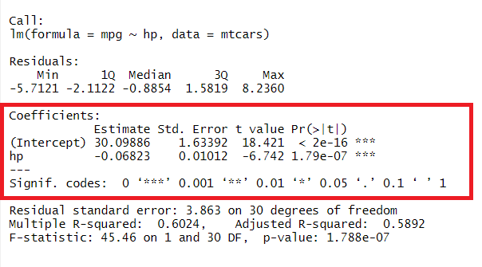

## Checking the model 1: Visually

Does the model look sensible?

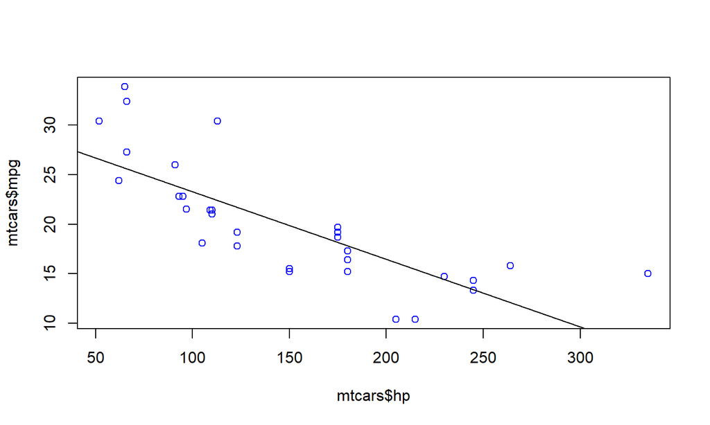

```r
plot(mtcars$hp, mtcars$mpg, col = "blue")
abline(model1)
```

## Checking the model 2: Residuals

The residuals have to be random, otherwise there is some non-random variation that our model doesn’t capture:

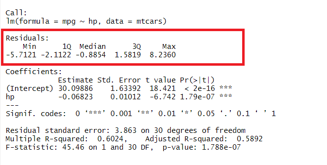

## Checking the model 2: Residuals

The residuals have to be random, otherwise there is some non-random variation that our model doesn’t capture:

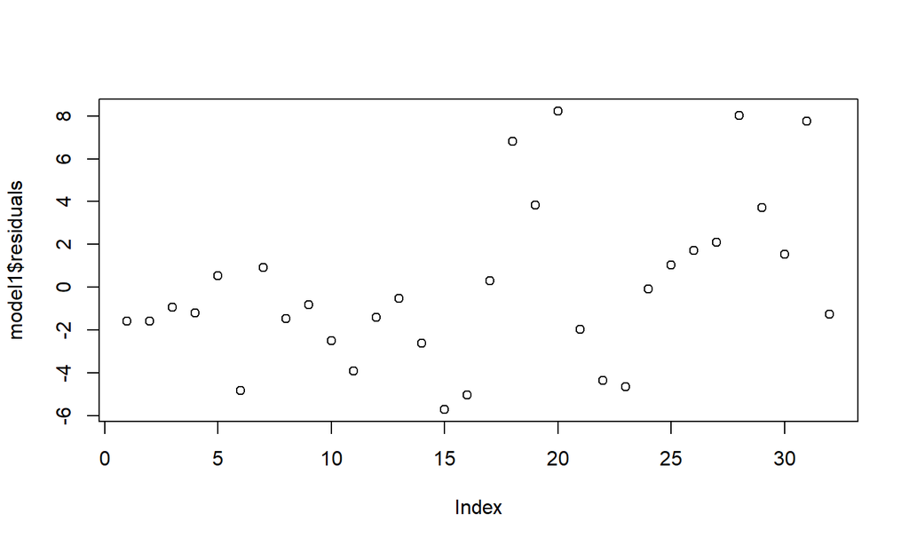

## Checking the model 3: R-squared

Check the adjusted R-squared, as the multiple R-squared will increase with more explanatory variables, even if they add nothing to the model. The adjusted R-squared gives a more accurate idea since it only increases if respecification of the model reduces the overall error of the predictions.

Recall that

\[R^2 = \frac{\textrm{Explained variation of the model}}{\textrm{Total variation of the model}}\]

## Checking the model 3: R-squared

Recall that it is the adjusted R-squared that most accurately records the suitability of the fit.

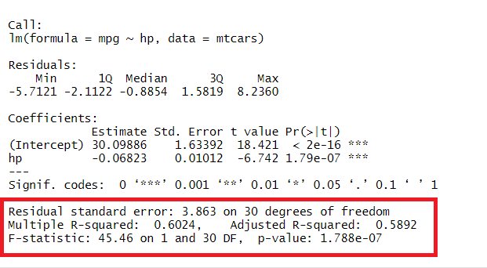

## Models with more terms

The dataset `Pressure` records pressure and temperature. It is constructed for this example, but based on actual data.

```r
Pressure
```

```
##    temperature  pressure
## 1           10  1.180916
## 2           20  2.255916
## 3           30  3.380916
## 4           40  4.555916
## 5           50  5.780916
## 6           60  7.055916
## 7           70  8.380916
## 8           80  9.755916
## 9           90 11.180916
## 10         100 12.655916
## 11         110 14.180916
## 12         120 15.755916
## 13         130 17.380916
## 14         140 19.055916
## 15         150 20.780916
## 16         160 22.555916
## 17         170 24.380916
## 18         180 26.255916
## 19         190 28.180916
## 20         200 30.155916
## 21         210 32.180916
## 22         220 34.255916
## 23         230 36.380916
## 24         240 38.555916
## 25         250 40.780916
```

## First attempt

We try to model pressure as a function of temperature:

```r
model2 <- lm(pressure ~ temperature, data = Pressure)
summary(model2)
```

```
##
## Call:
## lm(formula = pressure ~ temperature, data = Pressure)
##
## Residuals:
##    Min     1Q Median     3Q    Max
## -1.300 -1.075 -0.400  0.725  2.300
##
## Coefficients:
##              Estimate Std. Error t value Pr(>|t|)
## (Intercept) -2.769084   0.498623  -5.553 1.19e-05 ***
## temperature  0.165000   0.003354  49.193  < 2e-16 ***
## ---
## Signif. codes:  0 '***' 0.001 '**' 0.01 '*' 0.05 '.' 0.1 ' ' 1
##
## Residual standard error: 1.209 on 23 degrees of freedom
## Multiple R-squared:  0.9906, Adjusted R-squared:  0.9902
## F-statistic:  2420 on 1 and 23 DF,  p-value: < 2.2e-16
```

## Visual Inspection

Does the model look sensible?

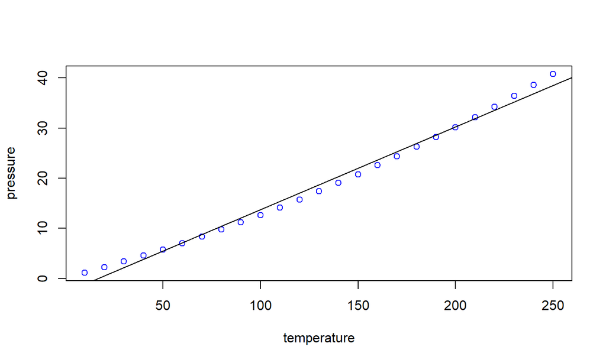

```r
plot(Pressure, col = "blue")
abline(model2)
```

## Residuals

Do the residuals look random?

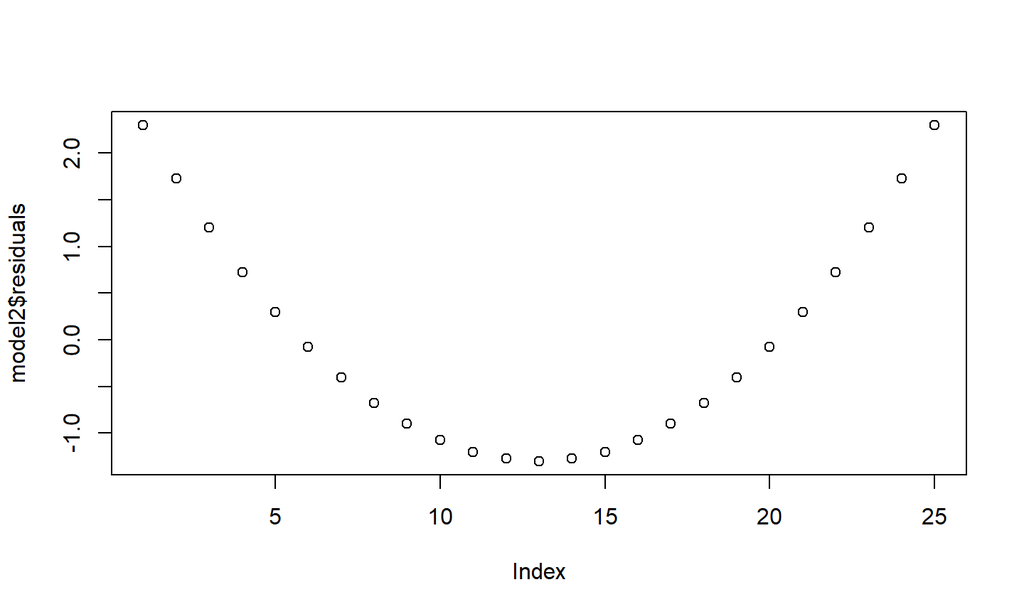

## Remodelling with a second order term

If you want to add a transformed term, just add an “I” (capital I) in front of your transformation term:

```r
model2_2 <- lm(pressure ~ temperature + I(temperature^2), data = Pressure)
summary(model2_2)
```

```
##
## Call:
## lm(formula = pressure ~ temperature + I(temperature^2), data = Pressure)
##
## Residuals:
##        Min         1Q     Median         3Q        Max
## -1.765e-14 -2.217e-15 -2.151e-16  1.175e-15  2.440e-14
##
## Coefficients:
##                   Estimate Std. Error   t value Pr(>|t|)
## (Intercept)      1.559e-01  4.401e-15 3.543e+13   <2e-16 ***
## temperature      1.000e-01  7.800e-17 1.282e+15   <2e-16 ***
## I(temperature^2) 2.500e-04  2.912e-19 8.585e+14   <2e-16 ***
## ---
## Signif. codes:  0 '***' 0.001 '**' 0.01 '*' 0.05 '.' 0.1 ' ' 1
##
## Residual standard error: 6.756e-15 on 22 degrees of freedom
## Multiple R-squared:      1,  Adjusted R-squared:      1
## F-statistic: 3.914e+31 on 2 and 22 DF,  p-value: < 2.2e-16
```

## Visual Inspection of residuals

As this model has more than one term, the plot function doesn’t plot it properly. But we can still plot the residuals. Do they look random?

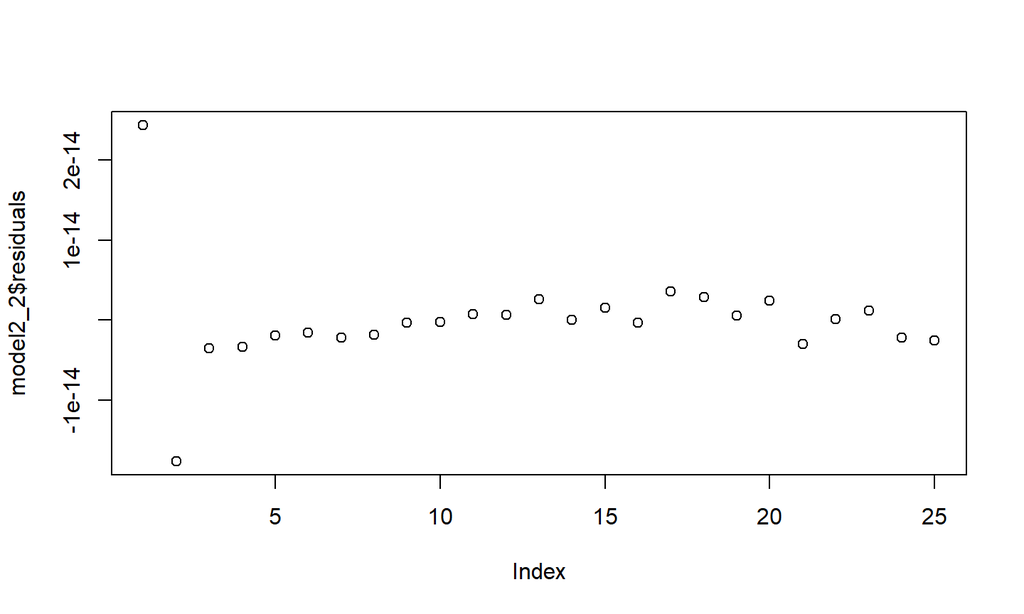

```r
plot(model2_2$residuals)
```

## A note on reducing the number of explanatory variables I

If you specify your model with too many explanatory variables, we say that it is over-fitted.

This may be an issue because the model fits your data too well, but doesn’t generalise to other data. After all, part of the reason for modelling data is to be able to predict values for unpaired variables, so we seek a balance between explanatory power and generalisability.

In order to include an explanatory variable (or predictor) in your model, there should be a logical reason why it would have explanatory power, and it should be significant according to the model summary.

## A note on reducing the number of explanatory variables II

Another way of doing it is the following:

- Start with the model that contains all potential predictors
- Remove one predictor at a time
- Keep this model if it improves the measure of accuracy (adjusted R-squared)
- Iterate until no further improvement is made.